# Real Scientist DE Umfrage

Vom 06.01.2020 bis zum 12.01.2020 habe ich den Twitter Account [Real Scientist DE](https://twitter.com/realsci_DE) übernommen. Dort berichtet jede Woche ein anderer Wissenschaftler über seine Forschung und seinen Arbeitsalltag. Ich habe in meiner Zeit als Kuratorin eine Umfrage durchgeführt, welche Aspekte wissenschaftlichen Arbeitens nach Ansicht der Follower schon in der Schule vermittelt werden sollten. Die Umfrage mit dem genauen Wortlaut der Fragen gibt es [hier](https://twitter.com/realsci_DE/status/1215910593695223808). Hier die Auswertung.

Zunächst einmal wurde wissenschaftliche Methodik bei vielen in der Schule gar nicht vermittelt.

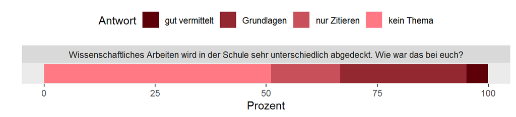

Hier sind die Ergebnisse, wie wichtig die Follower einzelne Aspekte wissenschaftlichen Arbeitens fanden. Dabei sind die einzelnen Aspekte nach Wichtigkeit geordnet: Ich habe die Wichtigkeit jedes Aspekts berechnet, indem die Antwort “sehr wichtig” mit 2 gewichtet wurde, “wichtig” mit 1, “nicht so wichtig” mit - 1 und “überhaupt nicht wichtig” mit - 2.

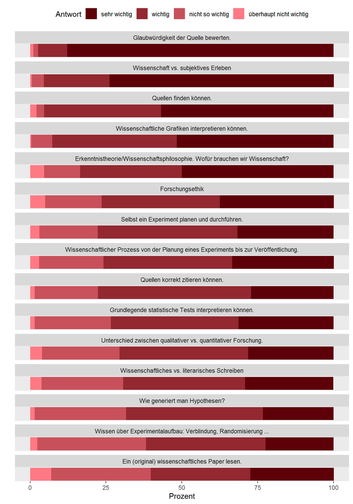

Bonusrunde: So ist die Anzahl der Teilnehmer an der Umfrage von Tweet zu Tweet gesunken (die Eingangsfrage danach, wie sehr wissenschaftliche Methodik vermittelt wurde, mit einbezogen):

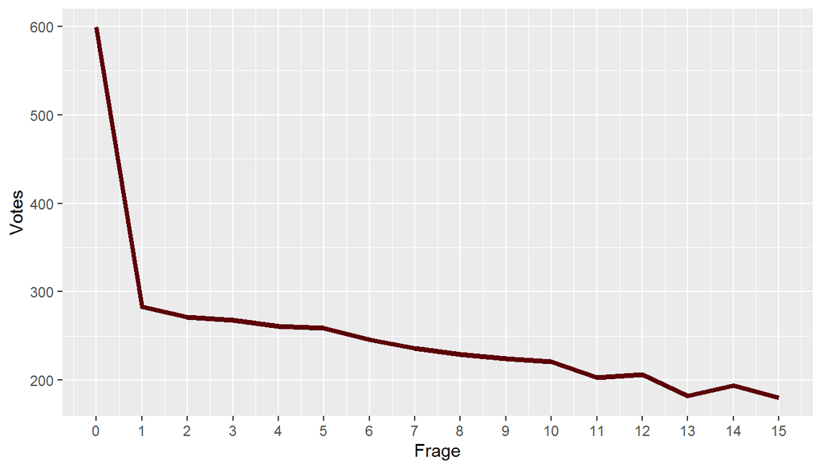